```python
import pandas as pd
import numpy as np
import matplotlib.pyplot as plt
import seaborn as sns
import scipy.stats as stats
```

# Введение

Возьмем пуассоновское распределение

$$ f(x) = \frac{\lambda^x}{x!}e^{-\lambda} $$

Пусть $\lambda = 4$

```python
lam = 4
```

# Задание 1

Напоминим, что $M_X = \lambda$

## Сгенирируем выборки разных объемом и проиллюстрируем сходимость выборочного среднего к мат. ожиданию

Рассмотрим одну выборку

```python
# генирируем выборку
n_obs = 1000
x = np.random.poisson(lam, n_obs)
```

```python
# считаем кумулятивную сумму
x_cumsum = np.cumsum(x)
```

```python
# считаем среднее
x_mean = x_cumsum / np.arange(1, n_obs + 1)
```

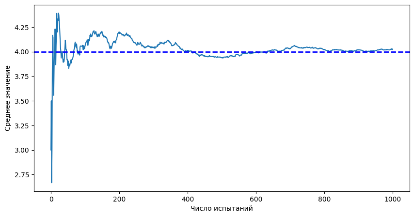

```python
plt.figure(figsize=(10, 5))
plt.plot(x_mean)
plt.axhline(lam, color='b', linestyle='dashed', linewidth=2)
plt.xlabel('Число испытаний')
plt.ylabel('Среднее значение')
plt.plot();
```

Рассмотрим выборки разного размера

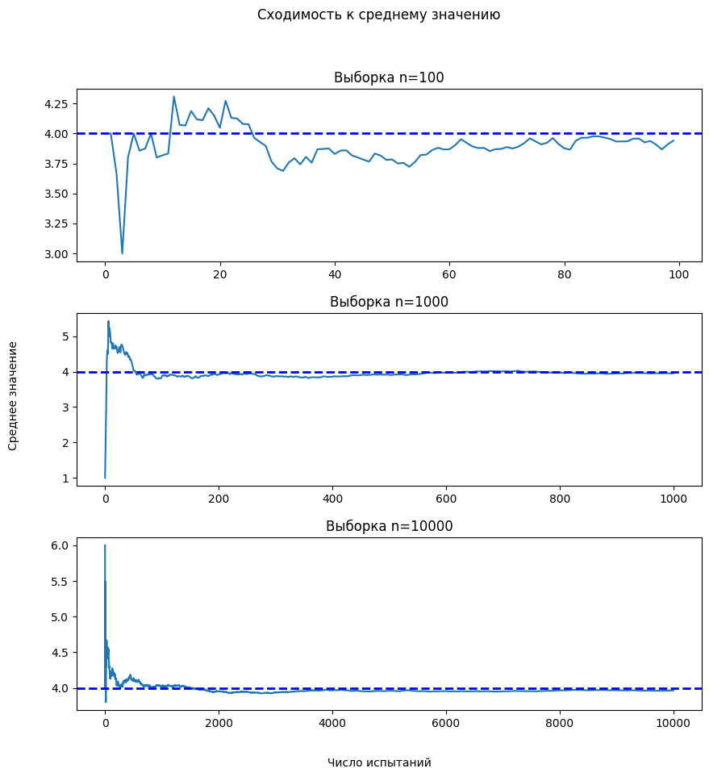

```python
fig, ax = plt.subplots(3, figsize=(10, 10))
fig.suptitle('Сходимость к среднему значению')
for i, n_obs in enumerate([100, 1000, 10000]):
    x = np.random.poisson(lam, n_obs)
    x_cumsum = np.cumsum(x)
    x_mean = x_cumsum / np.arange(1, n_obs + 1)
    ax[i].plot(x_mean)
    ax[i].axhline(lam, color='b', linestyle='dashed', linewidth=2)
    ax[i].set_title(f'Выборка n={n_obs}')
    ax[i].plot();

fig.text(0.5, 0.04, 'Число испытаний', ha='center')
fig.text(0.04, 0.5, 'Среднее значение', va='center', rotation='vertical')
fig.subplots_adjust(hspace=0.3)
```

**Несложно заметить, что с увеличением числа выборки ее среднее стремиться к истинному среднему**

**Вывод**: `ЗБЧ выполняется`

# Задание 2

Сгенерируем выборки

```python
n_samples = 10
n_obs = 10**6
x_arr = [np.random.poisson(lam, n_obs) for _ in range(n_samples)]
```

Отнормируем выборки, вычтем среднее и поделим на стандартное отклонение

```python
x_arr = [(x - x.mean()) / x.std() for x in x_arr]
```

Проиллюстрируем суммы выборок

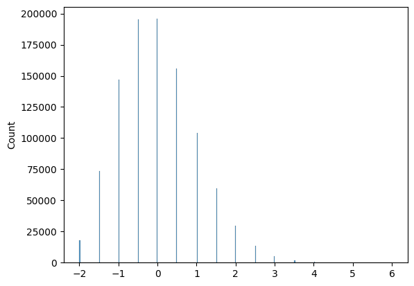

```python
sns.histplot(x_arr[0]);
```

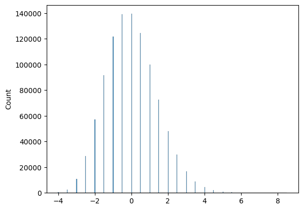

```python
sns.histplot(x_arr[0] +x_arr[1])
```

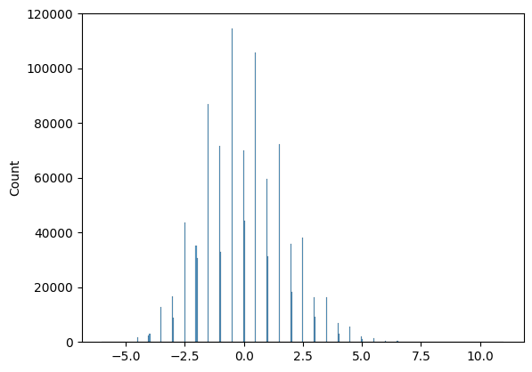

```python
sns.histplot(x_arr[0] +x_arr[1] + x_arr[2])
```

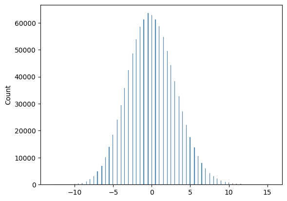

```python
sns.histplot(sum(x_arr));
```

# Задание 3

```python
data = {
    "Асимпотитечкий доверительный интервал": {},
    "Точный доверительный интервал": {},
}
```

```python
n_obs = [15, 100, 1000]
samples = [np.random.poisson(lam, n) for n in n_obs]
```

## **Асимпотитечкий доверительный интервал**

$$\bar{x} \pm z_{1 - \frac{\alpha}{2}} . \sqrt{\frac{\bar{s}^2}{n}}$$

```python
def asymptotic_confidence_interval(sample, n_obs, alpha=0.05) -> list[float]:
    """
    Строит 1 - alpha асимптотический доверительный интервал
    """
    mean = sample.mean()
    std = sample.std()
    z_crit = stats.norm(0, 1).ppf(1 - alpha / 2)
    left = mean - z_crit * (sample.std() / (n_obs**0.5))
    right = mean + z_crit * (sample.std() / (n_obs**0.5))

    return [left, right]
```

```python
for i in range(len(n_obs)):
    left, right = asymptotic_confidence_interval(samples[i],  n_obs[i])
    data["Асимпотитечкий доверительный интервал"][f"n = {n_obs[i]}"] = {
        "Статистика": "Среднее значение",
        "Истинное значение": lam,
        "Левая граница": left,
        "Правая граница": right,
        "Ширина": right - left
        }
```

```python
pd.DataFrame.from_dict({(i,j): data[i][j]
                           for i in data.keys()
                           for j in data[i].keys()},
                       orient='index')
```

|  |  | Статистика | Истинное значение | Левая граница | Правая граница | Ширина |
| --- | --- | --- | --- | --- | --- | --- |
| Асимпотитечкий доверительный интервал | n = 15 | Среднее значение | 4 | 2.784511 | 4.815489 | 2.030978 |
|  | n = 100 | Среднее значение | 4 | 3.650204 | 4.369796 | 0.719592 |
|  | n = 1000 | Среднее значение | 4 | 3.804857 | 4.049143 | 0.244286 |

## **Точный доверительный интервал**

$$\bar{x} \pm t_{1 - \frac{\alpha}{2}} . \sqrt{\frac{\bar{s}^2}{n}}$$

```python
def accurate_confidence_interval(sample, n_obs, alpha=0.05) -> list[float]:
    """
    Строит 1 - alpha точный доверительный интервал
    """
    mean = sample.mean()
    std = sample.std()
    t_rv =stats.t(n_obs - 1)
    t_crit = t_rv.ppf(1 - alpha / 2)

    left = mean - t_crit*(std / (n_obs**0.5))
    right = mean + t_crit*(std / (n_obs**0.5))

    return [left, right]
```

```python
for i in range(len(n_obs)):
    left, right = accurate_confidence_interval(samples[i],  n_obs[i])
    data["Точный доверительный интервал"][f"n = {n_obs[i]}"] = {
        "Статистика": "Среднее значение",
        "Истинное значение": lam,
        "Левая граница": left,
        "Правая граница": right,
        "Ширина": right - left
        }
```

```python
pd.DataFrame.from_dict({(i,j): data[i][j]
                           for i in data.keys()
                           for j in data[i].keys()},
                       orient='index')
```

|  |  | Статистика | Истинное значение | Левая граница | Правая граница | Ширина |
| --- | --- | --- | --- | --- | --- | --- |
| Асимпотитечкий доверительный интервал | n = 15 | Среднее значение | 4 | 2.784511 | 4.815489 | 2.030978 |
|  | n = 100 | Среднее значение | 4 | 3.650204 | 4.369796 | 0.719592 |
|  | n = 1000 | Среднее значение | 4 | 3.804857 | 4.049143 | 0.244286 |
| Точный доверительный интервал | n = 15 | Среднее значение | 4 | 2.688751 | 4.911249 | 2.222498 |
|  | n = 100 | Среднее значение | 4 | 3.645752 | 4.374248 | 0.728497 |
|  | n = 1000 | Среднее значение | 4 | 3.804709 | 4.049291 | 0.244583 |

## **Эфронов доверительный интервал**

```python
data = {
    "Среднее значение": {},
    "Медиана": {},
    "Мода": {},
    "Дисперсия": {}
}
```

```python
def bootstrap_confidence_interval(sample, stat, alpha=0.05):
    """
    Стоит эфронов 1 - alpha доверительный интервал для выбранной статистики stat
    """
    n = sample.shape[0]
    distribution_lst = []
    for _ in range(100):
        a_ = np.random.choice(sample, size=n, replace=True)
        distribution_lst.append(stat(a_))

    return np.percentile(distribution_lst, q=[alpha / 2 * 100, (1 - alpha / 2) * 100])
```

Найдем эфроновы интервалы для **среднего** (истинное значение - 4)

```python
for i in range(len(n_obs)):
    left, right = bootstrap_confidence_interval(samples[i],  np.mean)
    data["Среднее значение"][f"n = {n_obs[i]}"] = {
        "Истинное значение": lam,
        "Левая граница": left,
        "Правая граница": right,
        "Ширина": right - left
        }
```

Найдем эфроновы интервалы для **медианы** (истинное значение - 4)

```python
for i in range(len(n_obs)):
    left, right = bootstrap_confidence_interval(samples[i],  np.median)
    data["Медиана"][f"n = {n_obs[i]}"] = {
        "Истинное значение": lam,
        "Левая граница": left,
        "Правая граница": right,
        "Ширина": right - left
        }
```

Найдем эфроновы интервалы для **моды** (истинное значение - 4)

```python
from statistics import mode
```

```python
for i in range(len(n_obs)):
    left, right = bootstrap_confidence_interval(samples[i],  mode)
    data["Мода"][f"n = {n_obs[i]}"] = {
        "Истинное значение": lam,
        "Левая граница": left,
        "Правая граница": right,
        "Ширина": right - left
        }
```

Найдем эфроновы интервалы для **дисперсии** (истинное значение - 4)

```python
for i in range(len(n_obs)):
    left, right = bootstrap_confidence_interval(samples[i],  np.var)
    data["Дисперсия"][f"n = {n_obs[i]}"] = {
        "Истинное значение": lam,
        "Левая граница": left,
        "Правая граница": right,
        "Ширина": right - left
        }
```

```python
pd.DataFrame.from_dict({(i,j): data[i][j]
                           for i in data.keys()
                           for j in data[i].keys()},
                       orient='index')
```

|  |  | Истинное значение | Левая граница | Правая граница | Ширина |
| --- | --- | --- | --- | --- | --- |
| Среднее значение | n = 15 | 4 | 2.996667 | 5.076667 | 2.080000 |
|  | n = 100 | 4 | 3.700000 | 4.330500 | 0.630500 |
|  | n = 1000 | 4 | 3.810175 | 4.047100 | 0.236925 |
| Медиана | n = 15 | 4 | 3.000000 | 4.000000 | 1.000000 |
|  | n = 100 | 4 | 3.500000 | 4.000000 | 0.500000 |
|  | n = 1000 | 4 | 4.000000 | 4.000000 | 0.000000 |
| Мода | n = 15 | 4 | 3.000000 | 4.000000 | 1.000000 |
|  | n = 100 | 4 | 3.000000 | 5.000000 | 2.000000 |
|  | n = 1000 | 4 | 3.000000 | 4.000000 | 1.000000 |
| Дисперсия | n = 15 | 4 | 0.487556 | 8.344667 | 7.857111 |
|  | n = 100 | 4 | 2.496113 | 4.182697 | 1.686585 |
|  | n = 1000 | 4 | 3.481689 | 4.219491 | 0.737802 |

Для выборки размера `1000` была получена точечная оценка для медианы, которая соответствует истинному распределению.